# Lab 09 - Bootstrap Tests and P-Values

Nonparametric statistics ay 2022/2023

2022/10/20

*Disclaimer: The present material has been slightly adapted from the original R script prepared by me for the a.y. 2020/2021 Nonparametric statistics course. I hereby assume responsibility for any error that may be present in this document, I do apologise for them and invite you to let me know.*

```r
seed=2781991
B=100000
library(pbapply)
library(parallel)
```

Let’s start by generating some data

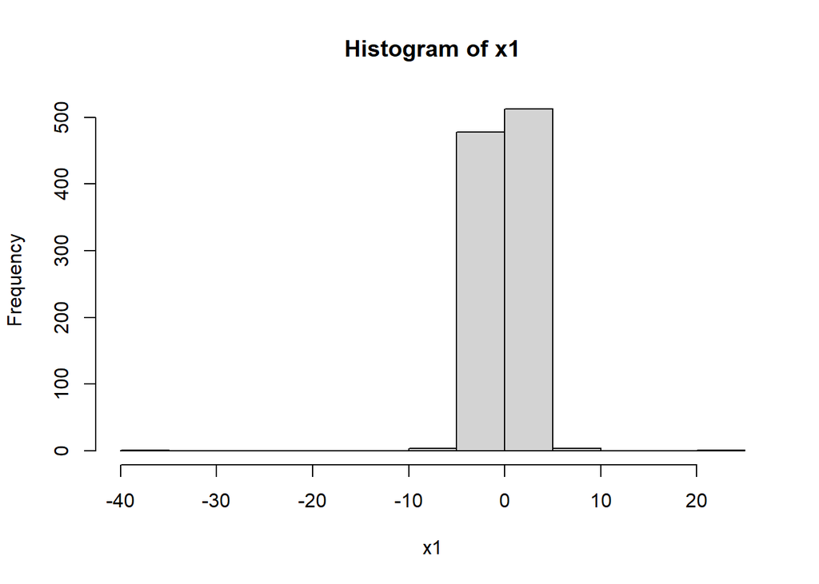

```r
set.seed(seed)
x1=stabledist::rstable(1000,1.8,0)

# Plot data
hist(x1)
```

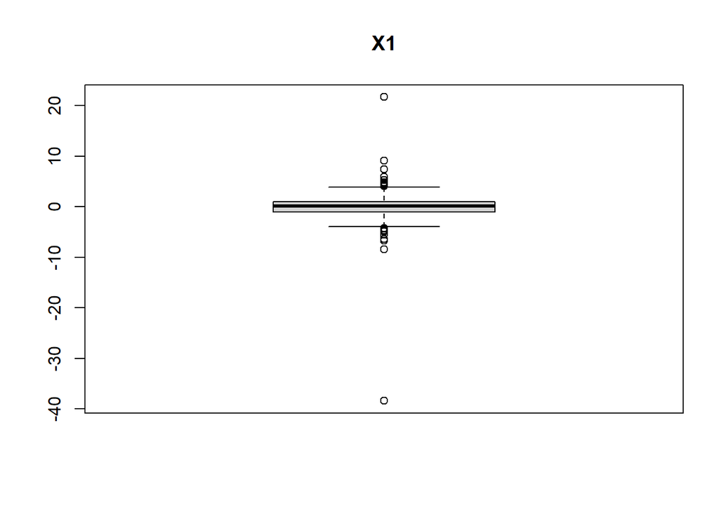

```r
boxplot(x1, main = 'X1')
```

We want to perform a test on the median of this distribution, namely $H_0:median(X_1)=0\;vs\;H_1:median(X_1)\neq0$. Let’s start by computing the sample median

```r
T.obs <- median(x1)
T.obs
```

```
## [1] 0.08967783
```

Now, we need to compute the bootstrap distribution of the sample median. To do this I will show you an advanced (and parallel…) technique. Let’s set up the cluster

```r
cl=makeCluster(parallel::detectCores())
clusterExport(cl=cl,list('x1'))
```

And now, let’s directly compute

```r
T.boot=pbreplicate(B,median(sample(x1, replace = T)))
```

Again, let’s observe the distribution

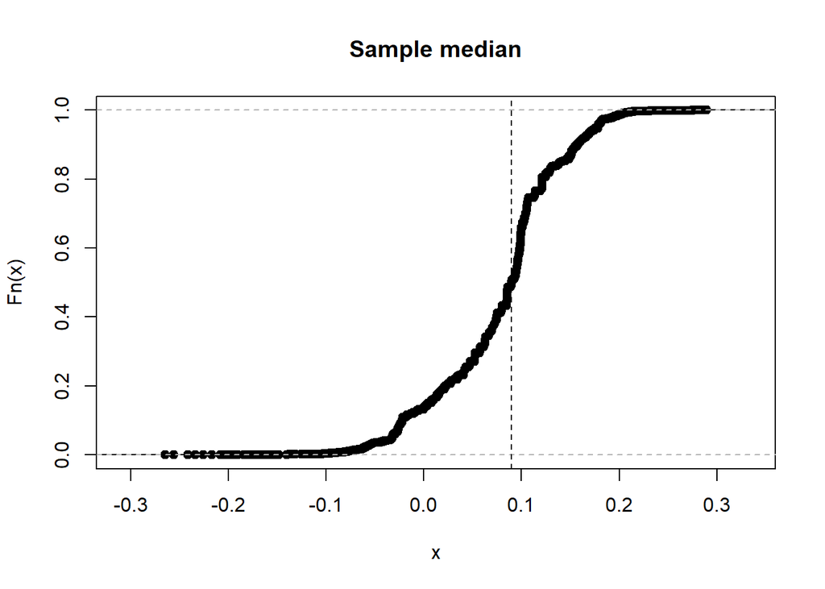

```r
plot(ecdf(T.boot), main='Sample median')
abline(v = T.obs, lty=2)
```

And compute the bias, variance, and RMSE

```r
var=var(T.boot)
var
```

```
## [1] 0.00399136
```

```r
bias=mean(T.boot)-T.obs
bias
```

```
## [1] -0.0116447
```

```r
RMSE=sqrt(var+bias^2)
RMSE
```

```
## [1] 0.06424141
```

We also know very well how to compute confidence intervals… so

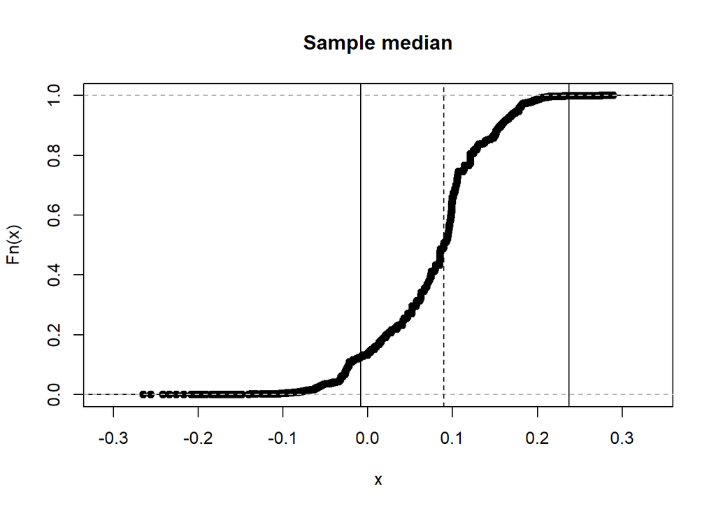

```r
alpha <- 0.05

right.quantile <- quantile(T.boot, 1 - alpha/2)
left.quantile  <- quantile(T.boot, alpha/2)



CI.RP <- c(T.obs - (right.quantile - T.obs), T.obs - (left.quantile - T.obs))
names(CI.RP)=c('lwr','upr')

plot(ecdf(T.boot), main='Sample median')
abline(v = T.obs, lty=2)
abline(v = CI.RP)
```

How do I compute the p-value of such test? I know that the p-value is the lowest alpha level for which I reject $H_0$. This value can be found via a grid search (that is computationally intensive, I know… but we know how to write fast code in R, don’t we?)

```r
alpha_grid=seq(0.001,0.5,by=0.001)
length(alpha_grid)
```

```
## [1] 500
```

Let’s compute the list of confidence intervals: I start by creating a function to be iterated…

```r
CI_calc=function(alpha_level){
  right.quantile <- quantile(T.boot, 1 - alpha_level/2)
  left.quantile  <- quantile(T.boot, alpha_level/2)
  out=c(T.obs - (right.quantile - T.obs), T.obs - (left.quantile - T.obs))
  names(out)=c('lwr','upr')
  return(out)
}
```

which I then iterate using lapply

```r
CI_list=pblapply(alpha_grid,CI_calc)
CI_mat=dplyr::bind_rows(CI_list)
```

And, I can now check if $0$ is contained in the CI… The values are sorted, so the first one that does not contain $0$ is the first one of the vector…

```r
check=CI_mat[,1]>0 | CI_mat[,2]<0
(alpha_grid[check])[1]
```

```
## [1] 0.081
```

So, I do not (expectedly…) reject $H_0$